# Regularization in Neural Networks

Shan-Hung Wu & DataLab  
Fall 2016

```python
from IPython.display import Image
from IPython.display import display

# inline plotting instead of popping out
%matplotlib inline

# load utility classes/functions that has been taught in previous labs
# e.g., plot_decision_regions()
import os, sys
module_path = os.path.abspath(os.path.join('.'))
sys.path.append(module_path)
from lib import *
```

Without sufficiently large datasets, deep neural networks with a large number of parameters may suffer from the over-fitting problem. In this lab, we will apply some regularization techniques to neural networks over the CIFAR-10 dataset and see how they improve the generalizability.

# The CIFAR-10 Dataset

[CIFAR-10](https://www.cs.toronto.edu/~kriz/cifar.html) consists of 60000 32x32 color images in 10 classes, with 6000 images per class. There are 50000 training images and 10000 test images. Here are the classes in the dataset, as well as 10 random images from each:

[figure not shown]

You can see that each image contains just **one** object in the corresponding class. This makes the object recognition task easy. For more realistic datasets where an image may contain multiple objects, you may refer to the [ImageNet](http://www.image-net.org/) dataset.

### Loading Data using Keras

Keras offers convenient facilities that automatically download some [well-known datasets](https://keras.io/datasets/) and store them in the `~/.keras/datasets` directory. Let's load the CIFAR-10 in Keras:

```python
from keras.datasets import cifar10
from keras.utils import np_utils

(X_train, y_train), (X_test, y_test) = cifar10.load_data()

# convert class vectors to binary vectors
Y_train = np_utils.to_categorical(y_train)
Y_test = np_utils.to_categorical(y_test)

print('X_train shape:', X_train.shape)
print('Y_train shape:', Y_train.shape)
print('X_test shape:', X_test.shape)
print('Y_test shape:', Y_test.shape)
```

```
X_train shape: (50000, 32, 32, 3)
Y_train shape: (50000, 10)
X_test shape: (10000, 32, 32, 3)
Y_test shape: (10000, 10)
```

NOTE: we assume that the TensorFlow image dimension ordering, i.e.,

`"image_dim_ordering": "tf"`

is set in the Keras config file `~/.keras/keras.json`. This is the default value.

### Loading Data Manually (Optional)

To know how it works under the hood, let's load CIFAR-10 by our own. According the [descripion](https://www.cs.toronto.edu/~kriz/cifar.html), the dataset file is divided into five training batches and one test batch, each with 10000 images. The test batch contains exactly 1000 randomly-selected images from each class. We define some constants based on the above:

```python
# dataset path
home = os.path.expanduser('~')
data_path = os.path.join(home, "data/CIFAR-10/")
data_url = "https://www.cs.toronto.edu/~kriz/cifar-10-python.tar.gz"

# CIFAR-10 constants
img_size = 32
img_channels = 3
nb_classes = 10
# length of the image after we flatten the image into a 1-D array
img_size_flat = img_size * img_size * img_channels
nb_files_train = 5
images_per_file = 10000
# number of all the images in the training dataset
nb_images_train = nb_files_train * images_per_file
```

We then define a function to download and extract the files from Internet:

```python
import urllib.request
import tarfile

def download_and_extract_cifar():
    if not os.path.exists(data_path):
        os.makedirs(data_path)

        file_path, _ = urllib.request.urlretrieve(url=data_url,
                                                  filename=os.path.join(data_path, 'cifar-10-python.tar.gz'),
                                                  reporthook=print_download_progress)
        print('\nExtracting... ', end='')
        tarfile.open(name=file_path, mode="r:gz").extractall(data_path)
        print('done')
    else:
        print("Data has already been downloaded and unpacked.")

download_and_extract_cifar()
```

```
Data has already been downloaded and unpacked.
```

Now we get a folder named `cifar-10-batches-py` containing the batch files. The next step is to load them into the memory:

```python
import _pickle as pickle
from keras.utils import np_utils
import numpy as np

def load_data(file_name):
    file_path = os.path.join(data_path, "cifar-10-batches-py/", file_name)

    print('Loading ' + file_name)
    with open(file_path, mode='rb') as file:
        data = pickle.load(file, encoding='bytes')
    raw_images = data[b'data']
    cls = np.array(data[b'labels'])

    images = raw_images.reshape([-1, img_channels, img_size, img_size])
    # move the channel dimension to the last
    images = np.rollaxis(images, 1, 4)

    return images, cls

def load_training_data():
    # pre-allocate the arrays for the images and class-numbers for efficiency.
    images = np.zeros(shape=[nb_images_train, img_size, img_size, img_channels],
                      dtype=int)
    cls = np.zeros(shape=[nb_images_train], dtype=int)

    begin = 0
    for i in range(nb_files_train):
        images_batch, cls_batch = load_data(file_name="data_batch_" + str(i + 1))
        num_images = len(images_batch)
        end = begin + num_images
        images[begin:end, :] = images_batch
        cls[begin:end] = cls_batch
        begin = end

    return images, np_utils.to_categorical(cls, nb_classes)

def load_test_data():
    images, cls = load_data(file_name="test_batch")

    return images, np_utils.to_categorical(cls, nb_classes)

def load_cifar():
    X_train, Y_train = load_training_data()
    X_test, Y_test = load_test_data()

    return X_train, Y_train, X_test, Y_test
```

```python
X_train, Y_train, X_test, Y_test = load_cifar()

print('\nX_train shape:', X_train.shape)
print('Y_train shape:', Y_train.shape)
print('X_test shape:', X_test.shape)
print('Y_test shape:', Y_test.shape)
```

```
Loading data_batch_1
Loading data_batch_2
Loading data_batch_3
Loading data_batch_4
Loading data_batch_5
Loading test_batch

X_train shape: (50000, 32, 32, 3)
Y_train shape: (50000, 10)
X_test shape: (10000, 32, 32, 3)
Y_test shape: (10000, 10)
```

### Data Preprocessing

The data are loaded as integers, so we need to cast it to floating point values in order to perform the division:

```python
# normalize inputs from 0-255 to 0.0-1.0
X_train = X_train.astype('float32')
X_test = X_test.astype('float32')
X_train = X_train / 255.0
X_test = X_test / 255.0
```

For simplicity, we also convert the images into the grayscale. We use the [Luma coding](https://en.wikipedia.org/wiki/Grayscale#Luma_coding_in_video_systems) that is common in video systems:

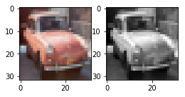

```python
import matplotlib.pyplot as plt

def grayscale(data, dtype='float32'):
    # luma coding weighted average in video systems
    r, g, b = np.asarray(.3, dtype=dtype), np.asarray(.59, dtype=dtype), np.asarray(.11, dtype=dtype)
    rst = r * data[:, :, :, 0] + g * data[:, :, :, 1] + b * data[:, :, :, 2]
    # add channel dimension
    rst = np.expand_dims(rst, axis=3)
    return rst

X_train_gray = grayscale(X_train)
X_test_gray = grayscale(X_test)

# now we have only one channel in the images
img_channels = 1

# plot a randomly chosen image
img = 64
plt.figure(figsize=(4, 2))
plt.subplot(1, 2, 1)
plt.imshow(X_train[img], interpolation='none')
plt.subplot(1, 2, 2)
plt.imshow(X_train_gray[img, :, :, 0], cmap=plt.get_cmap('gray'), interpolation='none')
plt.show()
```

As we can see, the objects in grayscale images can still be recognizable. Let's split the traning data to get a validation set:

```python
from sklearn.model_selection import train_test_split

X_train_gray, X_val_gray, Y_train, Y_val = train_test_split(X_train_gray, Y_train, test_size=0.2, random_state=0)

print('X_train_gray shape:', X_train_gray.shape)
print('X_val_gray shape:', X_val_gray.shape)
```

```
X_train_gray shape: (40000, 32, 32, 1)
X_val_gray shape: (10000, 32, 32, 1)
```

# Baseline Model

Let's compile an 8-layer dense NN as the baseline:

```python
from keras.callbacks import EarlyStopping

# define constants
batch_size = 128
epoch_max = 100
early_stop = EarlyStopping(monitor='val_loss', min_delta=0, patience=5, verbose=0)

def fit(model):
    hist = model.fit(X_train_gray, Y_train, \
                    batch_size=batch_size, \
                    nb_epoch=epoch_max, \
                    validation_data=(X_val_gray, Y_val), \
                    callbacks=[early_stop], \
                    shuffle=True, verbose=0)
    return hist

def evaluate(model, hist, plt_path):
    score = model.evaluate(X_test_gray, Y_test, verbose=0)
    print('Test loss: %.3f' % score[0])
    print('Test accuracy: %.3f' % score[1])
    plot_validation_history(hist, plt_path)
```

```
CPU times: user 19.8 s, sys: 2.58 s, total: 22.4 s
Wall time: 22.4 s
Test loss: 1.790
Test accuracy: 0.404
```

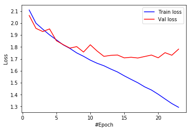

```python
from keras.models import Sequential
from keras.layers import Dense, Flatten

baseline = Sequential()
# flatten our input into an 1-D array
baseline.add(Flatten(input_shape=(img_size, img_size, img_channels)))
# hidden layers
for i in range(8):
    baseline.add(Dense(512, activation='relu'))
# output layer
baseline.add(Dense(nb_classes, activation='softmax'))

# compile model
baseline.compile(loss='categorical_crossentropy', optimizer='adam', metrics=['accuracy'])

# training & evaluatation
%time hist = fit(baseline)
evaluate(baseline, hist, 'output/fig-val-baseline.png')
```

The NN does learn something as it gives about 40% accuracy, which is clearly higher than that (10%) of random guess. However, we observe the issues of overfitting here—at the last few epochs, the validation/testing loss is much higher than the training loss. The model needs to be regularized to have better generalizability.

# Searching for Better Architecture

One way to improve the testing performance is to fine-tune the NN architecture. To avoid overfitting, we can reduce the model complexity by using fewer layers and/or decreasing the number of neurons in a layer. Let's see how an arbitrarily chosen architecture works:

```
CPU times: user 12.2 s, sys: 575 ms, total: 12.8 s
Wall time: 12.8 s
Test loss: 1.658
Test accuracy: 0.424
```

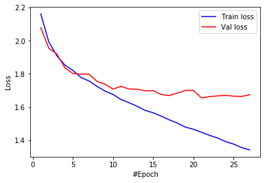

```python
baseline2 = Sequential()

# flatten our input into a single dimension array
baseline2.add(Flatten(input_shape=(img_size, img_size, img_channels)))
# hidden layers
baseline2.add(Dense(512, activation='relu'))
baseline2.add(Dense(256, activation='relu'))
baseline2.add(Dense(64, activation='relu'))
baseline2.add(Dense(32, activation='relu'))
# output layer
baseline2.add(Dense(nb_classes, activation='softmax'))

# compile model
baseline2.compile(loss='categorical_crossentropy', optimizer='adam', metrics=['accuracy'])

# training & evaluatation
%time hist = fit(baseline2)
evaluate(baseline2, hist, 'output/fig-val-baseline2.png')
```

The new architecture improves the testing accuracy, but the problem of overfitting remains.

We can continue this process to try out more models and then pick the best one. We can also use the grid-search to find out the best combination of the depth and width hyperparameters. However, this process is **very time consuming**, as there are too many hyperparameters (two at each layer) to search for. We need other regularization techniques.

# Weight Decay

Weight decay is a very common regularization technique. We have applied it to many previous models (e.g., regression, Logistic regression, SVM, etc.). For NNs, we can also penalize large weights in the cost function. This often comes in two flavors:

### $L^2$-Norm Penalties

The first way is add a term in the cost function that penalizes the $L^2$-norm of the weight matrix at each layer:

$$\arg\min_{\Theta=\{\boldsymbol{W}^{(1)}\cdots\boldsymbol{W}^{(L)}\}}C(\Theta)+\alpha\sum_{i=1}^{L}\Vert\boldsymbol{W}^{(i)}\Vert_{F}^{2}$$

This can be easily done in Keras by specifying the regularizer when adding a layer:

```
CPU times: user 55.5 s, sys: 11.9 s, total: 1min 7s
Wall time: 1min 7s
Test loss: 1.945
Test accuracy: 0.296
```

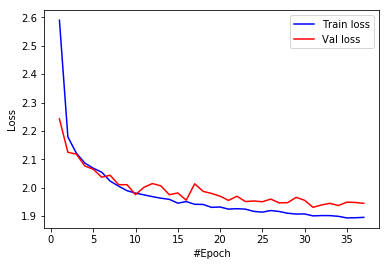

```python
from keras.regularizers import l2

model_l2 = Sequential()
# flatten our input into a single dimension array
model_l2.add(Flatten(input_shape=(img_size, img_size, img_channels)))

# hidden layers
l2_alpha = 0.0005
for i in range(8):
    # penalize the L2-norm of the weight matrix
    model_l2.add(Dense(512, activation='relu', W_regularizer=l2(l2_alpha)))
# output layer
model_l2.add(Dense(nb_classes, activation='softmax', W_regularizer=l2(l2_alpha)))

# compile model
model_l2.compile(loss='categorical_crossentropy', optimizer='adam', metrics=['accuracy'])
# training & evaluatation
%time hist = fit(model_l2)
evaluate(model_l2, hist, 'output/fig-val-model-l2.png')
```

The $L^2$-norm penalties reduces the gap between the training and validation loss. However, the testing accuracy is **not** improved. Forcing the weights to be around 0 limits the expressiveness of an NN and also creates **dead units** that output insignificant values without contributing much to the predictions.

### Explicit Weight Constraints

Alternatively, we can constrain the weights incident to each hidden unit to have a norm less than or equal to a desired value:

```
CPU times: user 39.9 s, sys: 5.38 s, total: 45.3 s
Wall time: 45.3 s
Test loss: 1.745
Test accuracy: 0.381
```

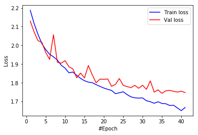

```python
from keras.constraints import maxnorm

model_c = Sequential()
# flatten our input into a single dimension array
model_c.add(Flatten(input_shape=(img_size, img_size, img_channels)))

# hidden layers
c_maxnorm = 0.7
for i in range(8):
    # constrain the weights incident to each hidden unit
    model_c.add(Dense(512, activation='relu', W_constraint=maxnorm(c_maxnorm)))
# output layer
model_c.add(Dense(nb_classes, activation='softmax', W_constraint=maxnorm(c_maxnorm)))

# compile model
model_c.compile(loss='categorical_crossentropy', optimizer='adam', metrics=['accuracy'])
# training & evaluatation
%time hist = fit(model_c)
evaluate(model_c, hist, 'output/fig-val-model-c.png')
```

Now we get a better test accuracy as compared to that of the $L^2$-norm penalties. The explicit weight constraint does not encourage small weights around 0, thus avoids **dead units** that do not contribute much to the behavior of an NN. However, it still limits the expressiveness of our NN. The testing accuracy is worse than the baseline.

# Batch Normalization

As discussed in the lecture, the idea of batch normalization is to explicitly force the activations of each layer to take on a unit Gaussian distribution over a batch of training examples. This makes the gradient-based optimization easier. At training time, we need to backprop through the normalization operation at each neuron. This is possible because the normalization operation is differentiable.

Although its main goal is to simplify the optimization task, batch normalization can improve the generalizability in a subtle way—during training, each example is "augmented" with the information in other examples in the same batch. This creates the effect similar to the noise augmentation that makes the NN more robust.

Keras offers the `BatchNormalization` layer. When using this layer, we need to make sure that it is added **after** the summation sublayer and **before** the non-linear activation sublayer:

```
CPU times: user 45 s, sys: 1.8 s, total: 46.8 s
Wall time: 46.7 s
Test loss: 1.694
Test accuracy: 0.425
```

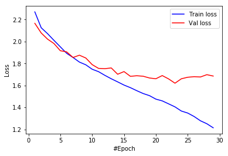

```python
from keras.layers import Activation
from keras.layers.normalization import BatchNormalization

model_bn = Sequential()

# flatten our input into a single dimension array
model_bn.add(Flatten(input_shape=(img_size, img_size, img_channels)))

# hidden layers
for i in range(8):
    model_bn.add(Dense(512))
    # add BatchNormalization after summation sublayer and before activation sublayer
    model_bn.add(BatchNormalization(mode=1))
    model_bn.add(Activation('relu'))
# output layer
model_bn.add(Dense(nb_classes, activation='softmax', W_constraint=maxnorm(drop_maxnorm)))

# compile model
model_bn.compile(loss='categorical_crossentropy', optimizer='adam', metrics=['accuracy'])
# training & evaluatation
%time hist = fit(model_bn)
evaluate(model_bn, hist, 'output/fig-val-model-bn.png')
```

We can see that the test accuracy is improved as compared to the baseline. However, batch normalization does not solve the overfitting problem.

NOTE: we use `mode=1` for fully connected layers. If you are using convolutional layers (in CNNs, to be discussed later), switch to `mode=0` and set the `axis` parameter to the channel dimension. See [documentation](https://keras.io/layers/normalization/).

# Dropout

As discussed in the lecture, the key idea of dropout is to randomly drop some units from the NN when processing a batch in training. This forces each neuron to learn to operate by its own instead of relying on other neurons. (Just like when you know your teammate is not that reliable, you have to take more responsibility when doing your final project.)

We can also think dropout as an ensemble technique where each batch trains a "thinned" network consisting of units that are not dropped out, as shown below:

[figure not shown]

At test time, the **weigh scaling** technique is commonly used—to make a prediction, we use the entire trained NN (with all units), but the weights going out from each unit is multiplied by the probability $p$ that a neuron is dropped out during the training time. This is to ensure that for any hidden unit the expected output at test time is the same as the output at training time.

In Keras, we can enable dropout by adding a `Dropout` layer after each (or a specific) ordinary layer, as below. Note that since each thinned network is trained by only a batch, we enable the batch normalization to make the training easier.

```
CPU times: user 1min 30s, sys: 2.19 s, total: 1min 33s
Wall time: 1min 35s
Test loss: 1.618
Test accuracy: 0.447
```

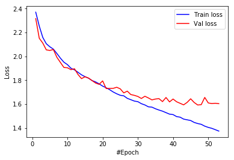

```python
from keras.layers import Activation
from keras.layers.normalization import BatchNormalization
from keras.layers import Dropout

model_drop = Sequential()

# flatten our input into a single dimension array
model_drop.add(Flatten(input_shape=(img_size, img_size, img_channels)))

# hidden layers
drop_rate = 0.2
for i in range(8):
    model_drop.add(Dense(512))
    model_drop.add(BatchNormalization(mode=1))
    model_drop.add(Activation('relu'))
    # dropout neurons randomly
    model_drop.add(Dropout(drop_rate))
# output layer
model_drop.add(Dense(nb_classes, activation='softmax'))

# compile model
model_drop.compile(loss='categorical_crossentropy', optimizer='adam', metrics=['accuracy'])
# training & evaluatation
%time hist = fit(model_drop)
evaluate(model_drop, hist, 'output/fig-val-model-drop.png')
```

We get a much better learning curve and improved testing accuracy. The dropout network requires more epochs to train.

NOTE: in cases where the NN does not overfit (when, e.g., there are a lot of training data), it may be better to increase the width (number of neurons) of each ordinary hidden layer when using dropout. See [discussions](https://www.cs.toronto.edu/~hinton/absps/JMLRdropout.pdf).

# Data Augmentation

NNs are known to be unrobust to noises/adversarial data points. One way to solve this problem is to "augment" each data point by a number of random transformations, provided that the transformations do not change the class labels of the point. With data augmentation, a model has a lower chance to see twice the exact same point. This helps prevent overfitting when dataset size is limited.

Keras provides the `ImageDataGenerator` class that can apply the following transformations to images:

- to rotate an image within `rotation_range` (0-180);
- to shift/translate an image vertically or horizontally within `width_shift` or `height_shift` (fraction of total width or height);
- to shear an image within `shear_range`;
- to zoom an image within `zoom_range`;
- to randomly flip an image horizontally, as indicated by the `horizontal_flip` flag;
- if the above transformations (e.g., rotation or width/height shift) creates new pixels, to fill image pixels following the mode specified by `fill_mode` (either `constant`, `nearest`, `reflect` or `wrap`).

Thre are [other transformations](https://keras.io/preprocessing/image/#imagedatagenerator) available. It is important to note that we should **not** apply a transformation that is going to affect the label. For example, if you apply a horizontal flip to an image representing the character 'b' in an OCR application, it will become 'd' and invalidate the associated label.

Below we visualize some images after augmentation.

[output not shown]

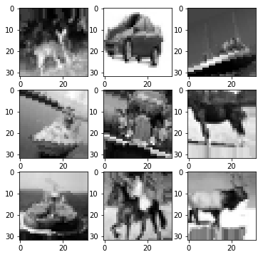

```python
from keras.preprocessing.image import ImageDataGenerator
import matplotlib.pyplot as plt

datagen = ImageDataGenerator(rotation_range=20, \
                             width_shift_range=0.1, \
                             height_shift_range=0.1, \
                             shear_range=0.1, \
                             zoom_range=0.2, \
                             horizontal_flip=True, \
                             fill_mode='nearest')

# visualize augmented points
plt.figure(figsize=(6, 6))
(X_batch, Y_batch) = datagen.flow(X_train_gray, Y_train, batch_size=9).next()
for i in range(9):
    plt.subplot(3, 3, (i + 1))
    plt.imshow(X_batch[i, :, :, 0], cmap=plt.get_cmap('gray'), interpolation='none')
plt.show()
```

We can see some occasional artifacts near the image edges. These are the filled pixels.

Let's feed the augmented data to our model (with batch normalization), as below. Note that the generator runs in parallel to the model fitting for efficiency. If you have a GPU, this means that your CPU does real-time data augmentation on images in parallel to the model fitting run on GPU.

```
/home/shwu/anaconda3/lib/python3.5/site-packages/keras/engine/training.py:1569: UserWarning: Epoch comprised more than `samples_per_epoch` samples, which might affect learning results. Set `samples_per_epoch` correctly to avoid this warning.
  warnings.warn('Epoch comprised more than '
```

```
CPU times: user 7min 43s, sys: 8.07 s, total: 7min 51s
Wall time: 7min 19s
Test loss: 1.504
Test accuracy: 0.469
```

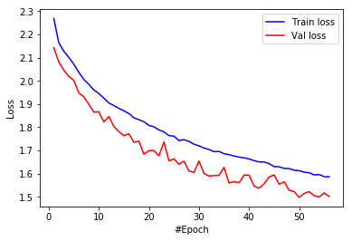

```python
from keras.layers import Activation
from keras.layers.normalization import BatchNormalization
from keras.layers import Dropout
from keras.preprocessing.image import ImageDataGenerator
import math

model_aug = Sequential()

# flatten our input into a single dimension array
model_aug.add(Flatten(input_shape=(img_size, img_size, img_channels)))

# hidden layers
for i in range(8):
    model_aug.add(Dense(512))
    model_aug.add(BatchNormalization(mode=1))
    model_aug.add(Activation('relu'))
# output layer
model_aug.add(Dense(nb_classes, activation='softmax'))

# compile model
model_aug.compile(loss='categorical_crossentropy', optimizer='adam', metrics=['accuracy'])

# training
%time hist = model_aug.fit_generator( \
                     datagen.flow(X_train_gray, Y_train, batch_size=batch_size), \
                     samples_per_epoch=X_train_gray.shape[0], \
                     nb_epoch=epoch_max, \
                     validation_data=(X_val_gray, Y_val), \
                     callbacks=[early_stop], \
                     verbose=0)

# evaluation
evaluate(model_aug, hist, 'output/fig-val-model-aug.png')
```

We see improved test accuracy. We also notice that the model **underfits** the dataset now. This is because the data augmentation effectively increases the number of training examples.

NOTE: we see a warning complaining about the `samples_per_epoch` setting. Normally, it should be a number that can be divided by the `batch_size`. For now, let's just ignore this warning.

Next, let's try to avoid the underfitting problem by increasing the width of hidden layers:

```
/home/shwu/anaconda3/lib/python3.5/site-packages/keras/engine/training.py:1569: UserWarning: Epoch comprised more than `samples_per_epoch` samples, which might affect learning results. Set `samples_per_epoch` correctly to avoid this warning.
  warnings.warn('Epoch comprised more than '
```

```
CPU times: user 12min 48s, sys: 20.8 s, total: 13min 8s
Wall time: 11min 45s
Test loss: 1.432
Test accuracy: 0.502
```

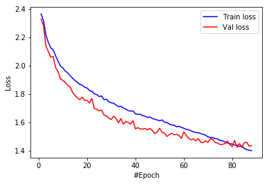

```python
model_aug2 = Sequential()

# flatten our input into a single dimension array
model_aug2.add(Flatten(input_shape=(img_size, img_size, img_channels)))

# hidden layers
for i in range(8):
    model_aug2.add(Dense(1024))
    model_aug2.add(BatchNormalization(mode=1))
    model_aug2.add(Activation('relu'))
# output layer
model_aug2.add(Dense(nb_classes, activation='softmax'))

# compile model
model_aug2.compile(loss='categorical_crossentropy', optimizer='adam', metrics=['accuracy'])

# training
%time hist = model_aug2.fit_generator( \
                     datagen.flow(X_train_gray, Y_train, batch_size=batch_size), \
                     samples_per_epoch=X_train_gray.shape[0], \
                     nb_epoch=epoch_max, \
                     validation_data=(X_val_gray, Y_val), \
                     callbacks=[early_stop], \
                     verbose=0)

# evaluation
evaluate(model_aug2, hist, 'output/fig-val-model-aug2.png')
```

Now we see a much better learning curve, as well as further improved test accuracy.

# Domain-Specific Design: CNN (Preview)

If done right, the domain-specific design can yield much better results than the above general regularization techniques. This is because it can incorporate the prior knowledge only available in the current domain.

Since we are classifying images, it is nature to use a Convolutional NN (CNN) that captures the **location-independent patterns** inside an image. We will discuss how CNNs work in the next lecture. For now, let's just do a quick preview and get some sense about the effectiveness of domain-specific design.

Turning our model into a CNN is quire easy. Instead of flatten the input, we can just feed it into a stack of convolutional and pooling layers:

```
Output shape of last concolution layers: (None, 4, 4, 32)
CPU times: user 1min 53s, sys: 31.4 s, total: 2min 24s
Wall time: 2min 26s
Test loss: 1.037
Test accuracy: 0.698
```

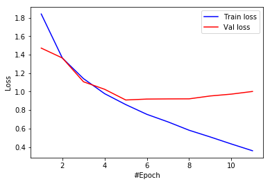

```python
from keras.layers.convolutional import Convolution2D, MaxPooling2D

model_cnn = Sequential()

# conolutional hidden layers
for i in range(6):
    model_cnn.add(Convolution2D(32, 3, 3,
                        input_shape=(img_size, img_size, img_channels),
                        border_mode='same', activation='relu'))
    if (i + 1) % 2 == 0:
        model_cnn.add(MaxPooling2D(pool_size=(2, 2), border_mode='same'))

print('Output shape of last concolution layers: {0}'.format(model_cnn.output_shape))
model_cnn.add(Flatten())

# fully connected hidden layers
for i in range(2):
    model_cnn.add(Dense(512))
    model_cnn.add(BatchNormalization(mode=1))
    model_cnn.add(Activation('relu'))

# output layer
model_cnn.add(Dense(nb_classes, activation='softmax'))

# compile model
model_cnn.compile(loss='categorical_crossentropy', optimizer='adam', metrics=['accuracy'])

# training & evaluatation
%time hist = fit(model_cnn)
evaluate(model_cnn, hist, 'output/fig-val-model-cnn.png')
```

We get a big jump in test accuracy! More surprisingly, we solve **fewer** variables in this CNN than in previous models:

```python
print('baseline: {0} parameters'.format(baseline.count_params()))
print('model_bn: {0} parameters'.format(model_bn.count_params()))
print('model_cnn: {0} parameters'.format(model_cnn.count_params()))
```

```
baseline: 2368522 parameters
model_bn: 2384906 parameters
model_cnn: 581098 parameters
```

Now you get some sense about how effective a domain-specific network could be. But we are not done yet. The current CNN has the overfitting problem. Let's train it using the augmented dataset:

```
Output shape of last concolution layers: (None, 4, 4, 32)
CPU times: user 10min 13s, sys: 1min 57s, total: 12min 11s
Wall time: 8min 38s
Test loss: 0.611
Test accuracy: 0.793
```

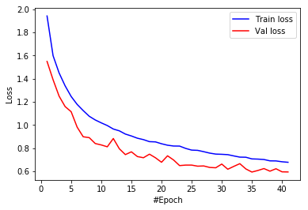

```python
model_cnn2 = Sequential()

# convolutional hidden layers
for i in range(6):
    model_cnn2.add(Convolution2D(32, 3, 3,
                        input_shape=(img_size, img_size, img_channels),
                        border_mode='same', activation='relu'))
    if (i + 1) % 2 == 0:
        model_cnn2.add(MaxPooling2D(pool_size=(2, 2), border_mode='same'))

print('Output shape of last concolution layers: {0}'.format(model_cnn2.output_shape))
model_cnn2.add(Flatten())

# fully connected hidden layers
for i in range(2):
    model_cnn2.add(Dense(512))
    model_cnn2.add(BatchNormalization(mode=1))
    model_cnn2.add(Activation('relu'))

# output layer
model_cnn2.add(Dense(nb_classes, activation='softmax'))

# compile model
model_cnn2.compile(loss='categorical_crossentropy', optimizer='adam', metrics=['accuracy'])

# training
%time hist = model_cnn2.fit_generator( \
                     datagen.flow(X_train_gray, Y_train, batch_size=batch_size), \
                     samples_per_epoch=X_train_gray.shape[0], \
                     nb_epoch=epoch_max, \
                     validation_data=(X_val_gray, Y_val), \
                     callbacks=[early_stop], \
                     verbose=0)

# evaluation
evaluate(model_cnn2, hist, 'output/fig-val-model-cnn2.png')
```

We get even better test accuracy now. Let's put what we have learned so far together. We increase the network size and add a dropout layer after each ordinary hidden layer:

```
Output shape of last concolution layers: (None, 4, 4, 64)
CPU times: user 19min 52s, sys: 4min 35s, total: 24min 27s
Wall time: 20min
Test loss: 0.526
Test accuracy: 0.820
```

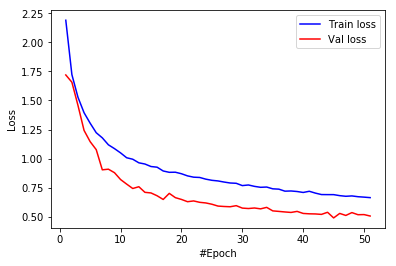

```python
model_cnn3 = Sequential()

# convolutional hidden layers
drop_rate = 0.2
for i in range(6):
    model_cnn3.add(Convolution2D(64, 3, 3,
                        input_shape=(img_size, img_size, img_channels),
                        border_mode='same', activation='relu'))
    model_cnn3.add(Dropout(drop_rate))
    if (i + 1) % 2 == 0:
        model_cnn3.add(MaxPooling2D(pool_size=(2, 2), border_mode='same'))

print('Output shape of last concolution layers: {0}'.format(model_cnn3.output_shape))
model_cnn3.add(Flatten())

# fully connected hidden layers
for i in range(2):
    model_cnn3.add(Dense(1024))
    model_cnn3.add(BatchNormalization(mode=1))
    model_cnn3.add(Activation('relu'))
    model_cnn3.add(Dropout(drop_rate))

# output layer
model_cnn3.add(Dense(nb_classes, activation='softmax'))

# compile model
model_cnn3.compile(loss='categorical_crossentropy', optimizer='adam', metrics=['accuracy'])

# training
%time hist = model_cnn3.fit_generator( \
                     datagen.flow(X_train_gray, Y_train, batch_size=batch_size), \
                     samples_per_epoch=X_train_gray.shape[0], \
                     nb_epoch=epoch_max, \
                     validation_data=(X_val_gray, Y_val), \
                     callbacks=[early_stop], \
                     verbose=0)

# evaluation
evaluate(model_cnn3, hist, 'output/fig-val-model-cnn3.png')
```

Finally, we get 82% test accuracy, which is twice as high as that of the baseline. This CNN has a similar number of parameters as the baseline:

```python
print('baseline: {0} parameters'.format(baseline.count_params()))
print('model_cnn3: {0} parameters'.format(model_cnn3.count_params()))
```

```
baseline: 2368522 parameters
model_cnn3: 2302922 parameters
```

Now we have some hands on experience in NN regularization. You are encouraged to fine-tune the network architecture to walk around the underfitting problem we have right now :)

# Remarks

In this lab, we only used grayscale images. Color information is vital to get the the state-of-the-art performance (95% and 92% with and without data augmentation respectively). In the next lab, we will explore the internals of CNNs using color images. Happy training!